# Lab 4 LDA/QDA/Naive Bayes

Hu Sun

2/9/2021

# 1 Quick Review on the Theory

## 1.1 LDA

- Consider data $(\mathbf{x}_i,y_i), i=1,\dots,n$, where $\mathbf{x}_i \in \mathbb{R}^p$ and $y_i\in \{1,2,\dots,K\}$. Linear discriminant analysis (LDA) assumes that $\mathbf{X}|Y=k \sim N(\boldsymbol{\mu}_k,\Sigma)$. Furthermore, the prior probability of $Y$ is $p(Y=k) = \pi_k$. The LDA method estimates the parameters $\boldsymbol{\mu}_k,\pi_k,\Sigma$ for all $k$, denoted as $\hat{\boldsymbol{\mu}}_k,\hat{\pi}_k,\hat{\Sigma}$. And classify any new data point $\mathbf{x}_i^{*}$ based on the Bayes rule:

$$C(\mathbf{x}_i^{*}) = \underset{k}{\operatorname{argmax}} \hat{\pi}_k\cdot \hat{f}(\mathbf{x}_i|y_i=k)$$

- The method is entitled with “linear” because the decision boundary is linear (hyperplane). For example:

$$\log \frac{p(y=k|\mathbf{x})}{p(y=l|\mathbf{x})} = \log \frac{\pi_k}{\pi_l} - \frac12 (\boldsymbol{\mu}_k + \boldsymbol{\mu}_l)^{T}\Sigma^{-1}(\boldsymbol{\mu}_k - \boldsymbol{\mu}_l) + \mathbf{x}^T\Sigma^{-1}(\boldsymbol{\mu}_k-\boldsymbol{\mu}_l)$$

- The above quantity, when equals to zero, defines the decision boundary spliting classes k and l. And it is linear in terms of $\mathbf{x}$. The vector $\Sigma^{-1}(\boldsymbol{\mu}_k-\boldsymbol{\mu}_l)$ is called **discriminant direction**. Note that in practice, the decision boundary should have the estimated $\hat{\boldsymbol{\mu}}_k,\hat{\pi}_k,\hat{\Sigma}$ in place of $\boldsymbol{\mu}_k,\pi_k,\Sigma$.
- Number of parameters to estimate: $K-1$ (class prior) + $K\cdot p$ (class mean) + $p(p+1)/2$ (shared covariance matrix).
- Estimation of all parameters requires that in aggregate, we have a sample size $n > p$.

## 1.2 QDA

- Similar to LDA, quadratic discriminant analysis (QDA) also assumes a normal distribution on $X|Y=k$. The only difference is that $\mathbf{X}|Y=k \sim N(\boldsymbol{\mu}_k,\Sigma_k)$, where the covariance matrix is no longer shared across different conditional densities. It is called “quadratic” because the decision boundary is a quadratic form of $\boldsymbol{x}^{*}$.
- Number of parameters to estimate: $K-1$ (class prior) + $K\cdot p$ (class mean) + $K\cdot p(p+1)/2$ (class-specific covariance matrix).
- Estimation of class-specific covariance matrix requires that for each group, we have a sample size $n_k > p$.

## 1.3 Naive Bayes

- Similar to the setup of LDA and QDA, we have data $(\mathbf{x}_i,y_i), i=1,\dots,n$, where $\mathbf{x}_i \in \mathbb{R}^p$ and $y_i\in \{1,2,\dots,K\}$. But Naive Bayes (NB) assumes conditional independence of predictors of $\mathbf{x}_i$ given $y_i$:

$$f(x_1,x_2,\dots,x_p|y) = f(x_1|y)\cdot f(x_2|y) \cdot \dots\cdot f(x_p|y)$$
where $(x_1,x_2,\dots,x_p)$ is a feature vector.

- Typically, the conditional density above is further assumed to be jointly normal. Given this normality assumption, NB is a simplified LDA with a diagonal $\Sigma$ matrix (zero correlation between variables due to conditional independence).
- Number of parameters to estimate: $K-1$ (class prior) + $K\cdot p$ (class mean) + $p$ (diagonal covariance matrix). NB has much fewer number of parameters compared to LDA and QDA when p is large.
- When $p$ is large, typically for bias: NB > LDA > QDA, and for variance: QDA > LDA > NB.

# 2 Programming with R

## 2.1 Preparations

### 2.1.1 Data and Train-test-split

We will use the `iris` dataset to illustrate LDA and QDA. `Species` is a three-level categorical variable. We will use it as the target of classification.

We will split each class proportionately for training and testing. We will take 70% of the Setosa irises, 70% of the Virginica irises, and 70% of the Versicolor irises to be in the training set.

```r
set.seed(123) # for reproducibility
table(iris$Species)
```

```
##
##     setosa versicolor  virginica
##         50         50         50
```

```r
iris_setosa = which(iris$Species == "setosa")
iris_versi = which(iris$Species == "versicolor")
iris_virg = which(iris$Species == "virginica")
train_id = c(sample(iris_setosa, size = trunc(0.70 * length(iris_setosa))),
             sample(iris_versi, size = trunc(0.70 * length(iris_versi))),
             sample(iris_virg, size = trunc(0.70 * length(iris_virg))))
iris_train = iris[train_id, ]
iris_test = iris[-train_id, ]
```

### 2.1.2 Data Visualization

Let’s explore the training data graphically to examine the relationship between `Species` and the other variables. Remember that our target is `Species`. This is a categorical variable! So we will use different colors or symbols to distinguish them in the plots.

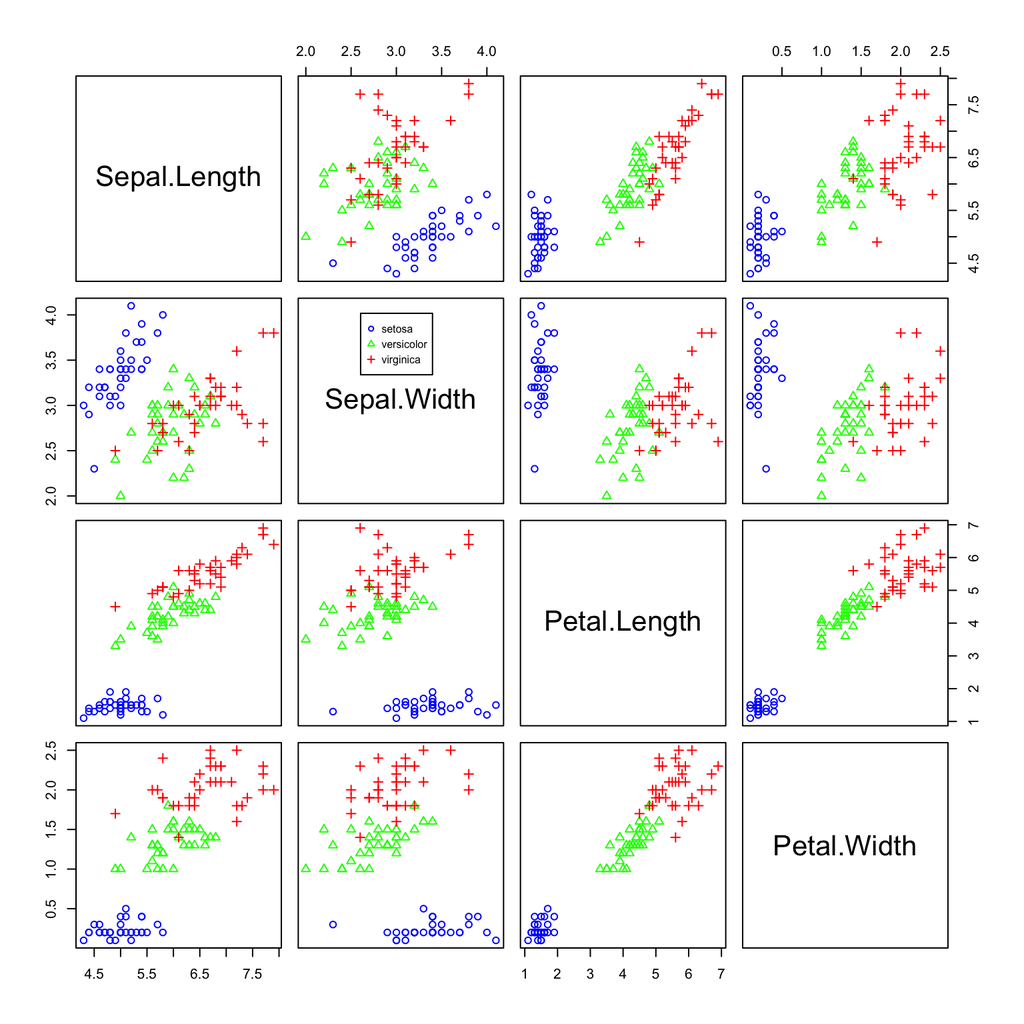

```r
pairs(iris_train[1:4], col=c("blue", "green","red")[iris_train$Species],
      pch=c(1,2,3)[iris_train$Species])
par(xpd=TRUE)
legend(0.34, 0.71, as.vector(unique(iris_train$Species)),
       col=c("blue", "green", "red"), pch=1:3, cex = 0.5)
```

- `par(xpd=TRUE)` is just a graphical option that allows us to easily place the legend on this pairs scatterplot. Try commenting it out and running this chunk. You’ll notice that the legend fails to appear. (This is not super important to know.)
- Positioning the legend can be a little tricky. Fiddle with the first two arguments to place it in a good spot.

## 2.2 LDA

### 2.2.1 Fit `lda` model

To fit an LDA model, we use the `lda()` function from the `MASS` package.

```r
library(MASS)                                  # loads the MASS package
iris_lda = lda(Species ~ ., data = iris_train) # trains LDA model using iris_train
iris_lda                                       # look at the LDA model
```

```
## Call:
## lda(Species ~ ., data = iris_train)
##
## Prior probabilities of groups:
##     setosa versicolor  virginica
##  0.3333333  0.3333333  0.3333333
##
## Group means:
##            Sepal.Length Sepal.Width Petal.Length Petal.Width
## setosa         4.991429    3.365714     1.471429   0.2314286
## versicolor     5.942857    2.777143     4.262857   1.3285714
## virginica      6.631429    2.982857     5.591429   2.0342857
##
## Coefficients of linear discriminants:
##                     LD1         LD2
## Sepal.Length  0.8603517 -0.02531284
## Sepal.Width   1.3884435 -2.37490707
## Petal.Length -2.2730220  0.89795664
## Petal.Width  -2.9135037 -2.68733735
##
## Proportion of trace:
##   LD1   LD2
## 0.992 0.008
```

### 2.2.2 Visualize the linear discriminant

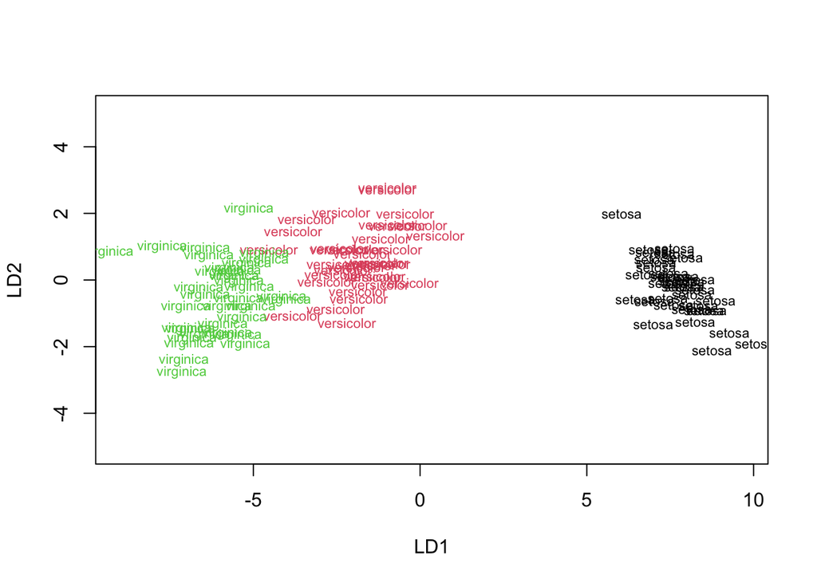

```r
plot(iris_lda, col = as.integer(iris_train$Species))
```

### 2.2.3 Visualize the partition with `klaR` package

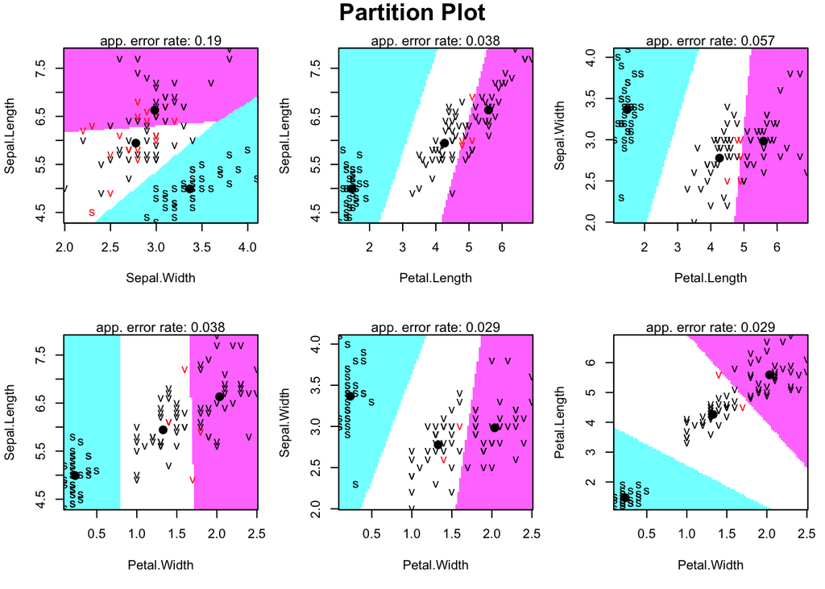

```r
# install.packages("klaR") # please install it if you have not
library(klaR)
partimat(Species ~ Sepal.Length + Sepal.Width + Petal.Length + Petal.Width, data=iris_train, method="lda")
```

### 2.2.4 Predict the test data

The `predict()` function operates in a new way when called on an `lda` object. By default, it returns an entire list. Within that list `class` stores the class predictions and `posterior` contains the estimated posterior probability for each class. If we want to extract the predictions or posterior probability estimates, we can do that with the `$` notation.

```r
names(predict(iris_lda, iris_test))
```

```
## [1] "class"     "posterior" "x"
```

```r
head(predict(iris_lda, iris_test)$class, n = 9)
```

```
## [1] setosa setosa setosa setosa setosa setosa setosa setosa setosa
## Levels: setosa versicolor virginica
```

```r
head(predict(iris_lda, iris_test)$posterior, n = 9)
```

```
##    setosa   versicolor    virginica
## 1       1 5.180307e-23 7.105444e-45
## 2       1 6.112832e-19 7.524191e-40
## 6       1 1.222997e-21 4.908094e-42
## 16      1 5.033088e-28 2.899621e-50
## 18      1 6.497181e-22 4.190740e-43
## 20      1 5.979798e-23 3.701092e-44
## 22      1 3.519153e-21 1.376569e-41
## 23      1 8.279076e-26 1.719910e-48
## 34      1 3.843511e-29 1.589131e-52
```

```r
lda.test = predict(iris_lda, iris_test)
iris_test$lda = lda.test$class
table(predicted = iris_test$lda, actual = iris_test$Species)
```

```
##             actual
## predicted    setosa versicolor virginica
##   setosa         15          0         0
##   versicolor      0         15         1
##   virginica       0          0        14
```

### 2.2.5 Training and testing error

We just fit an LDA model (`iris_lda`). Now let’s make predictions (for both the training and test observations):

```r
iris_lda_train_pred = predict(iris_lda, iris_train)$class
iris_lda_test_pred = predict(iris_lda, iris_test)$class
```

To calculate training and test error, do

```r
train_err = mean(iris_lda_train_pred != iris_train$Species)
test_err = mean(iris_lda_test_pred != iris_test$Species)
train_err
```

```
## [1] 0.01904762
```

```r
test_err
```

```
## [1] 0.02222222
```

## 2.3 QDA

### 2.3.1 Fit `qda` model

Like `lda()`, the `qda()` function is found in the `MASS` package.

```r
iris_qda = qda(Species ~ ., data = iris_train)
iris_qda
```

```
## Call:
## qda(Species ~ ., data = iris_train)
##
## Prior probabilities of groups:
##     setosa versicolor  virginica
##  0.3333333  0.3333333  0.3333333
##
## Group means:
##            Sepal.Length Sepal.Width Petal.Length Petal.Width
## setosa         4.991429    3.365714     1.471429   0.2314286
## versicolor     5.942857    2.777143     4.262857   1.3285714
## virginica      6.631429    2.982857     5.591429   2.0342857
```

### 2.3.2 Visualize the partition with `klaR` package

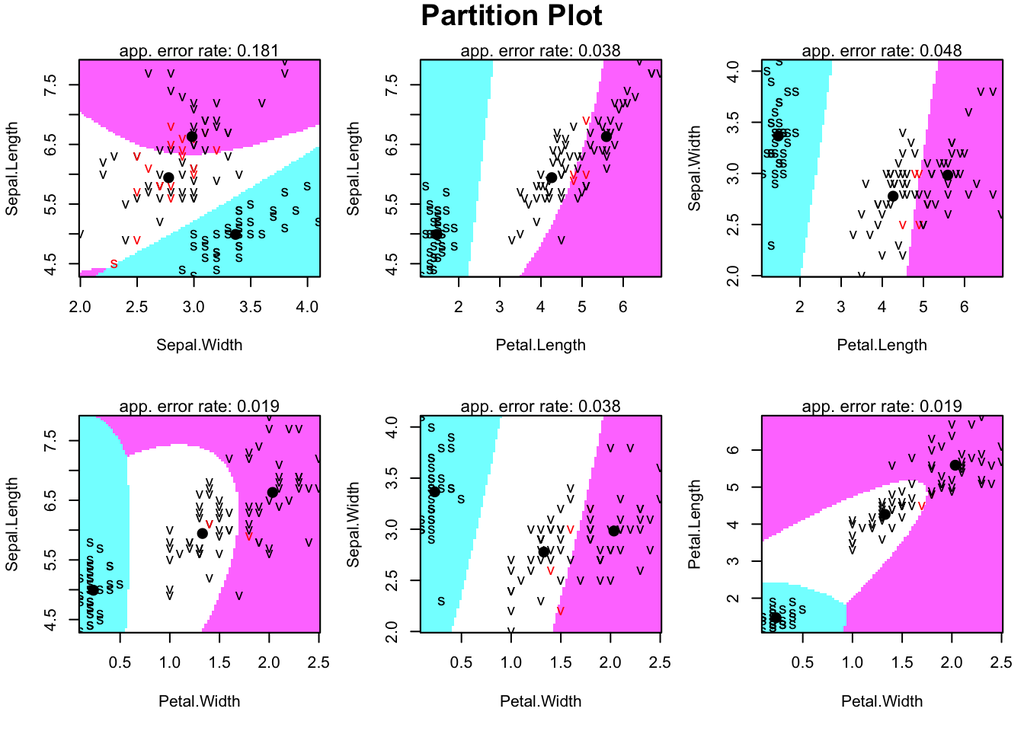

```r
# install.packages("klaR") # please install it if you have not
library(klaR)
partimat(Species ~ Sepal.Length + Sepal.Width + Petal.Length + Petal.Width, data=iris_train, method="qda")
```

### 2.3.3 Training and Testing Error

The `predict()` function operates the same as the `predict()` function for LDA.

```r
iris_qda_train_pred = predict(iris_qda, iris_train)$class
iris_qda_test_pred = predict(iris_qda, iris_test)$class
```

Here’s the training error, test error, and confusion matrix:

```r
train_err = mean(iris_qda_train_pred != iris_train$Species)
train_err
```

```
## [1] 0.00952381
```

```r
test_err = mean(iris_qda_test_pred != iris_test$Species)
test_err
```

```
## [1] 0.02222222
```

```r
table(predicted = iris_qda_test_pred, actual = iris_test$Species)
```

```
##             actual
## predicted    setosa versicolor virginica
##   setosa         15          0         0
##   versicolor      0         15         1
##   virginica       0          0        14
```

## 2.4 Naive Bayes

### 2.4.1 About Data

We use `hsbdemo` dataset to try this method. The dataset contains variables on 200 students. The outcome variable is `prog`, program type: academic/general/vacational. The features contains the scores of several subjects, such as `reading`, `writing`, `math`, `science`, `social science` and others like `sex`, `school type`, `social economic status`, `honors`, `awards`. We are interested in how well we can predict a student’s program type using these related features.

#### 2.4.1.1 Load Dataset

```r
library(foreign)
mydata = read.dta("hsbdemo.dta")
head(mydata)
```

```
##    id female    ses schtyp     prog read write math science socst       honors
## 1  45 female    low public vocation   34    35   41      29    26 not enrolled
## 2 108   male middle public  general   34    33   41      36    36 not enrolled
## 3  15   male   high public vocation   39    39   44      26    42 not enrolled
## 4  67   male    low public vocation   37    37   42      33    32 not enrolled
## 5 153   male middle public vocation   39    31   40      39    51 not enrolled
## 6  51 female   high public  general   42    36   42      31    39 not enrolled
##   awards cid
## 1      0   1
## 2      0   1
## 3      0   1
## 4      0   1
## 5      0   1
## 6      0   1
```

```r
summary(mydata[mydata$prog=="vocation",])
```

```
##        id            female       ses         schtyp         prog
##  Min.   :  1.00   male  :23   low   :12   public :48   general : 0
##  1st Qu.: 44.25   female:27   middle:31   private: 2   academic: 0
##  Median : 86.00               high  : 7                vocation:50
##  Mean   : 88.40
##  3rd Qu.:140.75
##  Max.   :184.00
##       read          write            math          science          socst
##  Min.   :31.0   Min.   :31.00   Min.   :33.00   Min.   :26.00   Min.   :26.00
##  1st Qu.:39.5   1st Qu.:40.25   1st Qu.:40.00   1st Qu.:39.00   1st Qu.:36.00
##  Median :47.0   Median :46.00   Median :45.00   Median :47.00   Median :46.00
##  Mean   :46.2   Mean   :46.76   Mean   :46.42   Mean   :47.22   Mean   :45.02
##  3rd Qu.:50.0   3rd Qu.:53.50   3rd Qu.:51.75   3rd Qu.:53.75   3rd Qu.:51.00
##  Max.   :68.0   Max.   :67.00   Max.   :75.00   Max.   :72.00   Max.   :66.00
##           honors       awards          cid
##  not enrolled:44   Min.   :0.00   Min.   : 1.00
##  enrolled    : 6   1st Qu.:0.00   1st Qu.: 2.00
##                    Median :0.00   Median : 5.00
##                    Mean   :0.76   Mean   : 6.44
##                    3rd Qu.:1.00   3rd Qu.:10.00
##                    Max.   :7.00   Max.   :20.00
```

```r
summary(mydata[mydata$prog=="academic",])
```

```
##        id           female       ses         schtyp         prog
##  Min.   :  3.0   male  :47   low   :19   public :81   general :  0
##  1st Qu.: 57.0   female:58   middle:44   private:24   academic:105
##  Median :104.0               high  :42                vocation:  0
##  Mean   :107.6
##  3rd Qu.:166.0
##  Max.   :200.0
##       read           write            math          science         socst
##  Min.   :34.00   Min.   :33.00   Min.   :38.00   Min.   :31.0   Min.   :31.0
##  1st Qu.:47.00   1st Qu.:52.00   1st Qu.:50.00   1st Qu.:48.0   1st Qu.:51.0
##  Median :55.00   Median :59.00   Median :57.00   Median :55.0   Median :56.0
##  Mean   :56.16   Mean   :56.26   Mean   :56.73   Mean   :53.8   Mean   :56.7
##  3rd Qu.:63.00   3rd Qu.:62.00   3rd Qu.:63.00   3rd Qu.:61.0   3rd Qu.:61.0
##  Max.   :76.00   Max.   :67.00   Max.   :75.00   Max.   :69.0   Max.   :71.0
##           honors       awards           cid
##  not enrolled:65   Min.   :0.000   Min.   : 2.00
##  enrolled    :40   1st Qu.:1.000   1st Qu.: 9.00
##                    Median :2.000   Median :13.00
##                    Mean   :2.248   Mean   :12.77
##                    3rd Qu.:3.000   3rd Qu.:17.00
##                    Max.   :7.000   Max.   :20.00
```

We remove the id and cid from the columns, since they cannot be meaningful predictors.

```r
mydata <- mydata[,-1]
mydata <- mydata[,-ncol(mydata)]
```

#### 2.4.1.2 Train-test-split

We will make a 70/30 partitioning for the training and test set.

```r
set.seed(231)
mydata_general = which(mydata$prog=="general")
mydata_academic = which(mydata$prog=="academic")
mydata_vocation = which(mydata$prog=="vocation")
trainIndex = c(sample(mydata_general, size = trunc(0.70 * length(mydata_general))),
             sample(mydata_academic, size = trunc(0.70 * length(mydata_academic))),
             sample(mydata_vocation, size = trunc(0.70 * length(mydata_vocation))))
train=mydata[trainIndex, ]
test=mydata[-trainIndex, ]
```

### 2.4.2 Fit NB model with `e1071` package

Next, we use the training data to fit the Naive Bayes classifier using `science` and `math` as predictors

```r
library(e1071)
NBclassfier=naiveBayes(prog~science+math, data=train)
print(NBclassfier)
```

```
##
## Naive Bayes Classifier for Discrete Predictors
##
## Call:
## naiveBayes.default(x = X, y = Y, laplace = laplace)
##
## A-priori probabilities:
## Y
##   general  academic  vocation
## 0.2230216 0.5251799 0.2517986
##
## Conditional probabilities:
##           science
## Y              [,1]      [,2]
##   general  51.87097  9.807283
##   academic 53.49315  9.453282
##   vocation 47.97143 10.942324
##
##           math
## Y              [,1]     [,2]
##   general  49.19355 7.082464
##   academic 56.39726 8.926770
##   vocation 47.22857 8.506350
```

The naiveBayes function assumed gaussian distributions for numeric varibles. Also, the priori are calculated from the porportion of the training data. The prioris are shown when the object is printed. The Y values are the means and standard deviations of the predictors within each class.

Now, let’s make predictions on training and test data and calculate the errors for both.

```r
pred_train = predict(NBclassfier,newdata = train)
mean(pred_train!=train$prog)
```

```
## [1] 0.4244604
```

```r
pred_test = predict(NBclassfier,newdata = test)
mean(pred_test!=test$prog)
```

```
## [1] 0.4098361
```

### 2.4.3 Refit NB with more predictors

Fit NB with more predictors can improve performances. Note how binary variable `schtyp` is modeled as Bernoulli instead of Gaussian.

```r
NBclassfier2=naiveBayes(prog~ses+science+socst+math+write+read+schtyp, data=train)
#NBclassfier2=naiveBayes(prog~., data=train)
print(NBclassfier2)
```

```
##
## Naive Bayes Classifier for Discrete Predictors
##
## Call:
## naiveBayes.default(x = X, y = Y, laplace = laplace)
##
## A-priori probabilities:
## Y
##   general  academic  vocation
## 0.2230216 0.5251799 0.2517986
##
## Conditional probabilities:
##           ses
## Y                low    middle      high
##   general  0.4193548 0.3870968 0.1935484
##   academic 0.1917808 0.4246575 0.3835616
##   vocation 0.2857143 0.5714286 0.1428571
##
##           science
## Y              [,1]      [,2]
##   general  51.87097  9.807283
##   academic 53.49315  9.453282
##   vocation 47.97143 10.942324
##
##           socst
## Y              [,1]      [,2]
##   general  50.87097  9.989134
##   academic 56.30137  9.793259
##   vocation 46.02857 10.589911
##
##           math
## Y              [,1]     [,2]
##   general  49.19355 7.082464
##   academic 56.39726 8.926770
##   vocation 47.22857 8.506350
##
##           write
## Y              [,1]     [,2]
##   general  52.00000 9.248423
##   academic 56.17808 7.865788
##   vocation 47.28571 9.672798
##
##           read
## Y              [,1]      [,2]
##   general  49.58065  9.157053
##   academic 55.98630 10.115298
##   vocation 47.91429  9.188776
##
##           schtyp
## Y              public    private
##   general  0.90322581 0.09677419
##   academic 0.75342466 0.24657534
##   vocation 0.97142857 0.02857143
```

```r
pred_train2 = predict(NBclassfier2,newdata = train)
mean(pred_train2!=train$prog)
```

```
## [1] 0.3669065
```

```r
pred_test2 = predict(NBclassfier2,newdata = test)
mean(pred_test2!=test$prog)
```

```
## [1] 0.3606557
```

### 2.4.4 Compare performances with LDA

```r
lda_classifier = lda(prog~ses+science+math, data=train)
pred_train2 = predict(lda_classifier,newdata = train)$class
mean(pred_train2!=train$prog)
```

```
## [1] 0.3956835
```

```r
pred_test2 = predict(lda_classifier,newdata = test)$class
mean(pred_test2!=test$prog)
```

```
## [1] 0.3606557
```